# FinalProject_TS_KatieBaerveldt

Katie B

10/7/2019

# Option #2: Reinforcement of Class Material

### *1. Perform a full time series EDA on cnt. Verify the statistical properties of the time series (cnt) and make any transformations as necessary. Run both visual and hypothesis driven tests. Discuss your conclusions.*

Data import & library setup:

```r
# Since I'm loading multiple packages at once, if there's an error loading a function later in the code I will repost a library() in case something is being masked #

library(tseries)
library(fBasics)
```

```r
library(ggplot2)
library(forecast)
library(moments)
library(fpp2)
library(seasonal)
library(urca)
library(stats)
library(data.table)
```

```r
bikes <- read.table('C:/Users/kbaer/Desktop/Katie/Time Series (Fall A 2019)/day.csv', header=T, sep=',')
head(bikes)
```

```
##   instant     dteday season yr mnth holiday weekday workingday weathersit
## 1       1 2011-01-01      1  0    1       0       6          0          2
## 2       2 2011-01-02      1  0    1       0       0          0          2
## 3       3 2011-01-03      1  0    1       0       1          1          1
## 4       4 2011-01-04      1  0    1       0       2          1          1
## 5       5 2011-01-05      1  0    1       0       3          1          1
## 6       6 2011-01-06      1  0    1       0       4          1          1
##       temp    atemp      hum windspeed casual registered  cnt
## 1 0.344167 0.363625 0.805833 0.1604460    331        654  985
## 2 0.363478 0.353739 0.696087 0.2485390    131        670  801
## 3 0.196364 0.189405 0.437273 0.2483090    120       1229 1349
## 4 0.200000 0.212122 0.590435 0.1602960    108       1454 1562
## 5 0.226957 0.229270 0.436957 0.1869000     82       1518 1600
## 6 0.204348 0.233209 0.518261 0.0895652     88       1518 1606
```

```r
class(bikes)
```

```
## [1] "data.frame"
```

Since there’s a leap year in the data, I followed the class notes on how to move forward:

```r
library(lubridate)
leap_year(2011)
```

```
## [1] FALSE
```

```r
leap_year(2012)
```

```
## [1] TRUE
```

```r
day_cnt.ts <- ts(bikes$cnt, start=decimal_date(as.Date("2011-01-01")), frequency = 365.25)
autoplot(day_cnt.ts)
```

```r
head(day_cnt.ts)
```

```
## Time Series:
## Start = 2011
## End = 2011.01368925394
## Frequency = 365.25
## [1]  985  801 1349 1562 1600 1606
```

```r
tail(day_cnt.ts)
```

```
## Time Series:
## Start = 2012.98494182067
## End = 2012.99863107461
## Frequency = 365.25
## [1]  441 2114 3095 1341 1796 2729
```

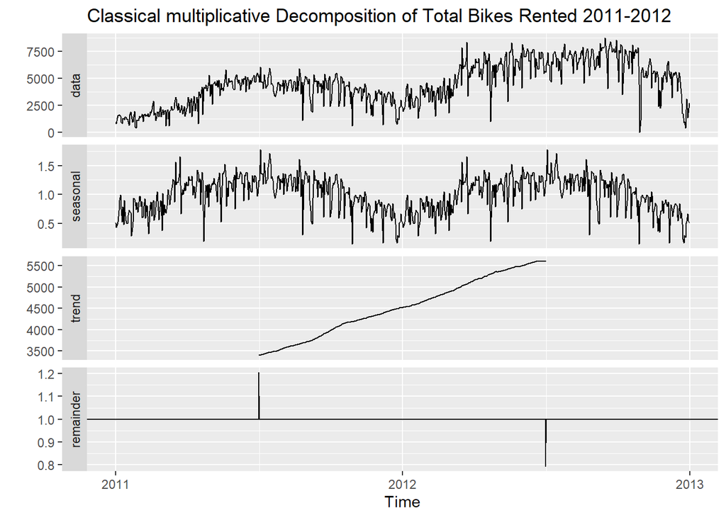

```r
day_cnt.ts %>% decompose(type="multiplicative") %>%
  autoplot() + xlab("Time") +
  ggtitle("Classical multiplicative Decomposition of Total Bikes Rented 2011-2012")
```

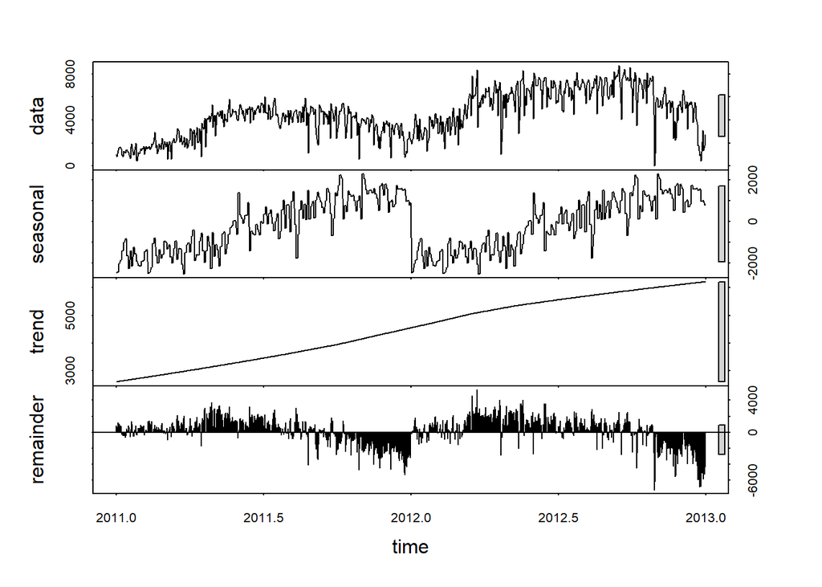

```r
plot(stl(day_cnt.ts, s.window="periodic"))
```

Though the raw data has peaks and valleys, the decomposition shows an overall updward trend in total bikes rented per day. Seasonality seems to depend mostly on hours of operation, and I sense there is a cyclical component (i.e. weather) at play.Transformation is necessary as we can see a pattern in the residuals.

Additional EDA and testing:

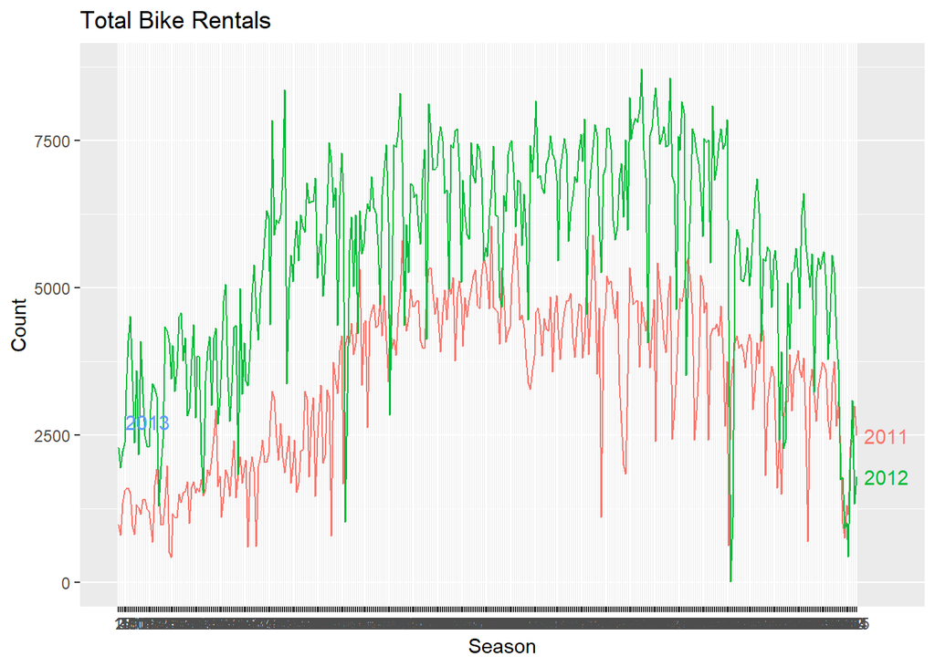

```r
ggseasonplot(day_cnt.ts, year.labels=TRUE, year.labels.left=FALSE) +
  ylab("Count") +
  ggtitle("Total Bike Rentals")
```

We can see trend differently here in the growth gap between 2011 and 2012. We can also see seasonality in the way the data mirrors itself year over year, however 2012 is showing some extreme events in the data.

```r
basicStats(day_cnt.ts)
```

```
##                day_cnt.ts
## nobs         7.310000e+02
## NAs          0.000000e+00
## Minimum      2.200000e+01
## Maximum      8.714000e+03
## 1. Quartile  3.152000e+03
## 3. Quartile  5.956000e+03
## Mean         4.504349e+03
## Median       4.548000e+03
## Sum          3.292679e+06
## SE Mean      7.165035e+01
## LCL Mean     4.363684e+03
## UCL Mean     4.645014e+03
## Variance     3.752788e+06
## Stdev        1.937211e+03
## Skewness    -4.715900e-02
## Kurtosis    -8.205510e-01
```

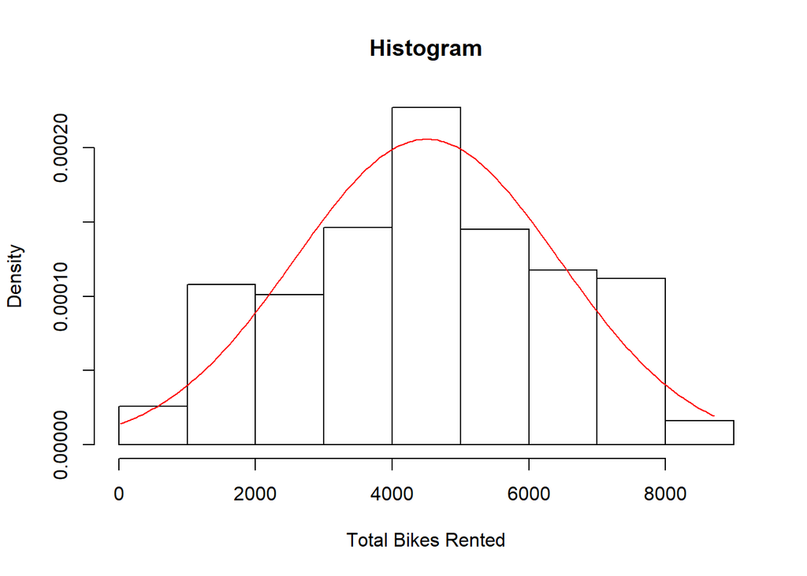

```r
hist(day_cnt.ts, xlab="Total Bikes Rented", prob=TRUE, main="Histogram")
xfit<-seq(min(day_cnt.ts),max(day_cnt.ts), length=192)
yfit<-dnorm(xfit,mean=mean(day_cnt.ts),sd=sd(day_cnt.ts))
lines(xfit, yfit, col="red", lwd=1)
```

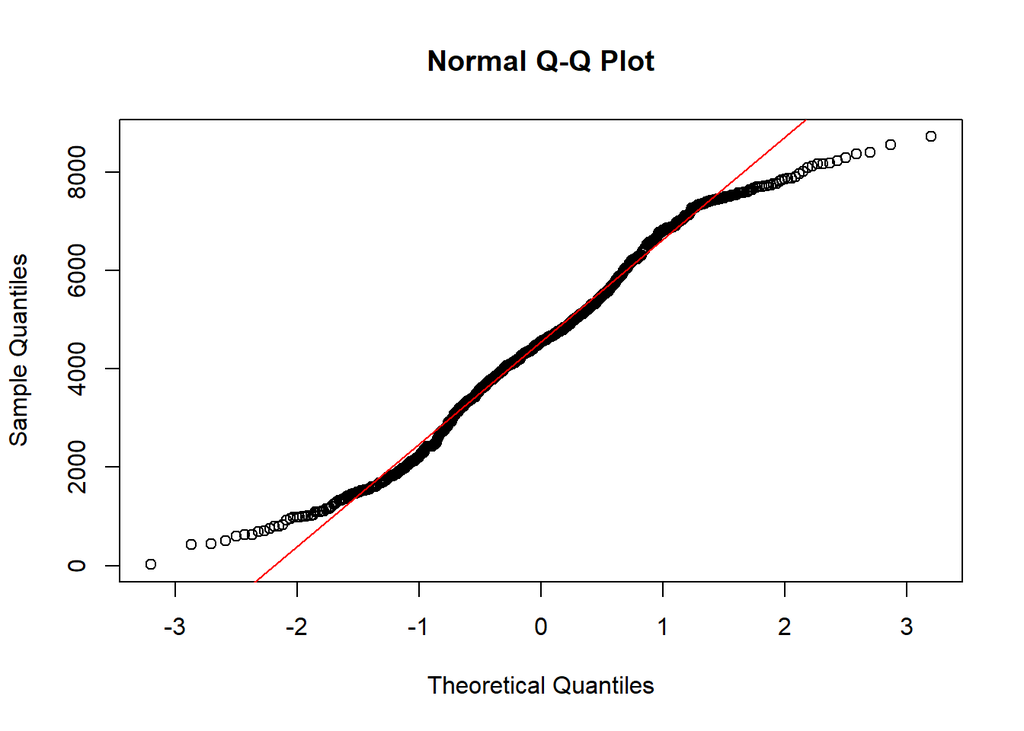

```r
qqnorm(day_cnt.ts)
qqline(day_cnt.ts, col = 2)
```

```r
skewness(day_cnt.ts)
```

```
## [1] -0.04725556
```

```r
kurtosis(day_cnt.ts)
```

```
## [1] 2.185424
```

From the histogram alone it appears there is a pretty even distribution, though some disparity is a little more visible from the Q-Q plot. The skewness score tells me the data distribution is very slightly left leaning, but kurtosis is low.

Testing normality with JB Test;

H0 = Data is normally distributed (p > 0.05) H1 = Data is not normally distributed (p < 0.05)

```r
normalTest(day_cnt.ts,method=c("jb"))
```

```
##
## Title:
##  Jarque - Bera Normalality Test
##
## Test Results:
##   STATISTIC:
##     X-squared: 20.4822
##   P VALUE:
##     Asymptotic p Value: 3.567e-05
##
## Description:
##  Mon Oct 14 21:43:06 2019 by user: kbaer
```

```r
Box.test(day_cnt.ts,lag=10,type='Ljung')
```

```
##
##  Box-Ljung test
##
## data:  day_cnt.ts
## X-squared = 4144.4, df = 10, p-value < 2.2e-16
```

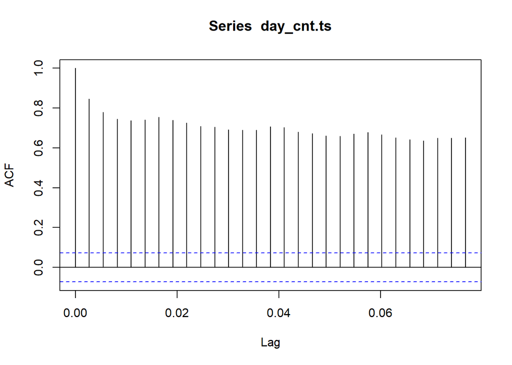

```r
acf(day_cnt.ts)
```

Both normality tests performed are telling me that I should reject H0, or the null hypothesis. The data needs to be transformed further in order to achieve stationary status. The ACF confirms that there is serial autocorrelation occuring in the data.

Log and BC testing:

```r
autoplot(day_cnt.ts)
```

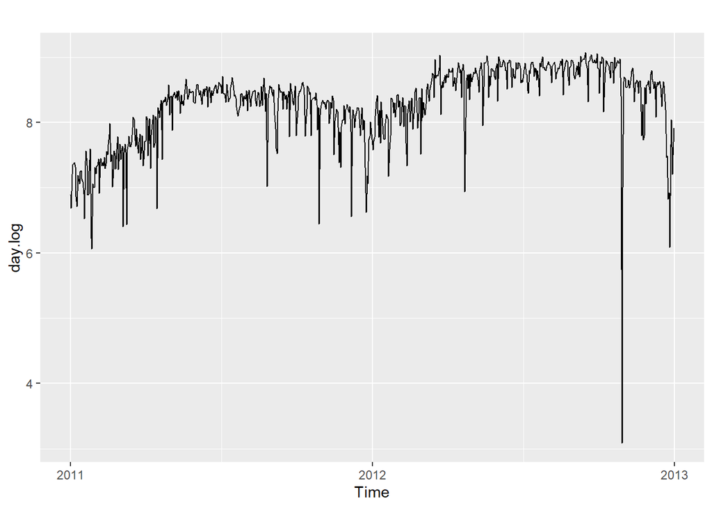

```r
day.log <- log(day_cnt.ts)
autoplot(day.log)
```

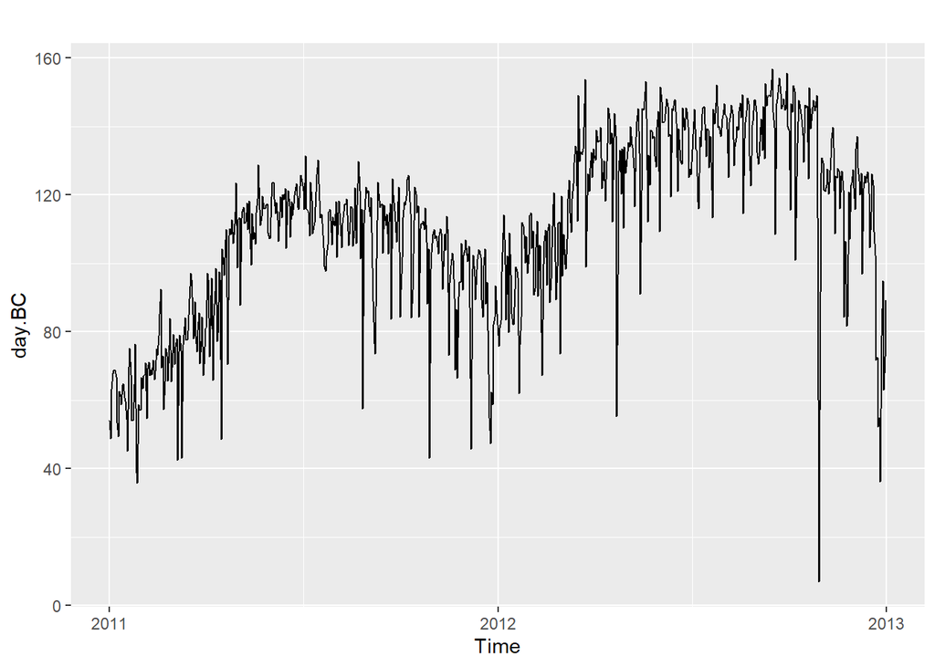

```r
day.BC <- BoxCox(day_cnt.ts, lambda="auto")
autoplot(day.BC)
```

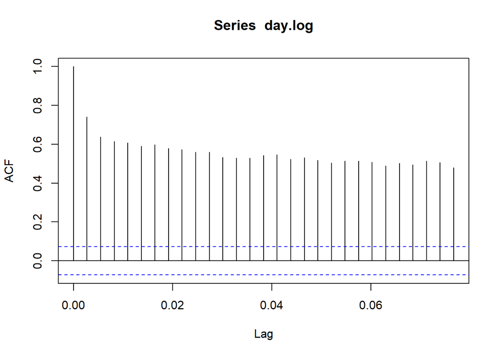

```r
acf(day.log)
```

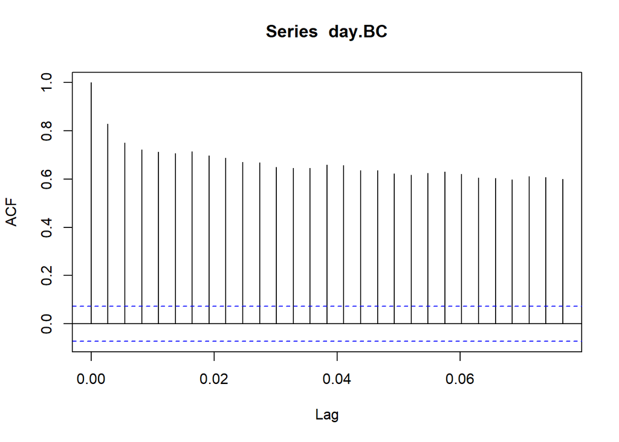

```r
acf(day.BC)
```

```r
normalTest(day.log,method=c("jb"))
```

```
##
## Title:
##  Jarque - Bera Normalality Test
##
## Test Results:
##   STATISTIC:
##     X-squared: 2875.5685
##   P VALUE:
##     Asymptotic p Value: < 2.2e-16
##
## Description:
##  Mon Oct 14 21:43:07 2019 by user: kbaer
```

```r
normalTest(day.BC,method=c("jb"))
```

```
##
## Title:
##  Jarque - Bera Normalality Test
##
## Test Results:
##   STATISTIC:
##     X-squared: 45.0061
##   P VALUE:
##     Asymptotic p Value: 1.687e-10
##
## Description:
##  Mon Oct 14 21:43:07 2019 by user: kbaer
```

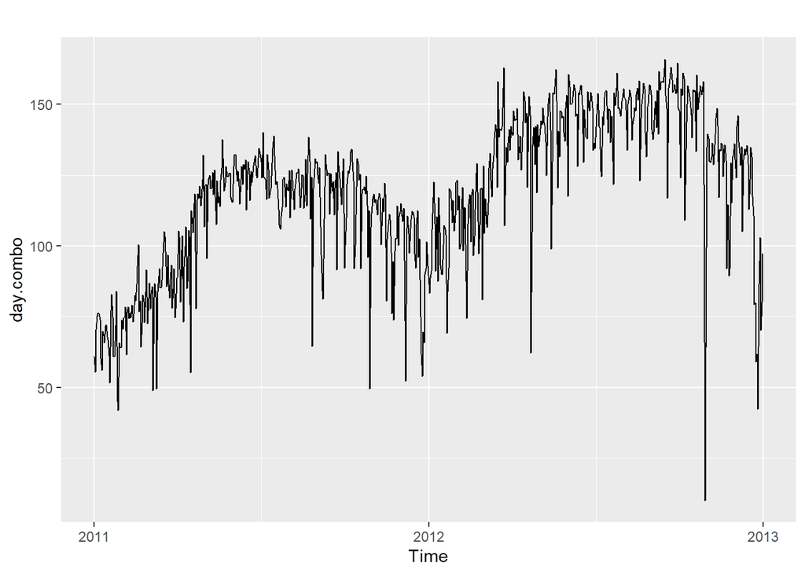

```r
day.combo <- (day.BC+day.log)
autoplot(day.combo)
```

```r
autoplot(day_cnt.ts)
```

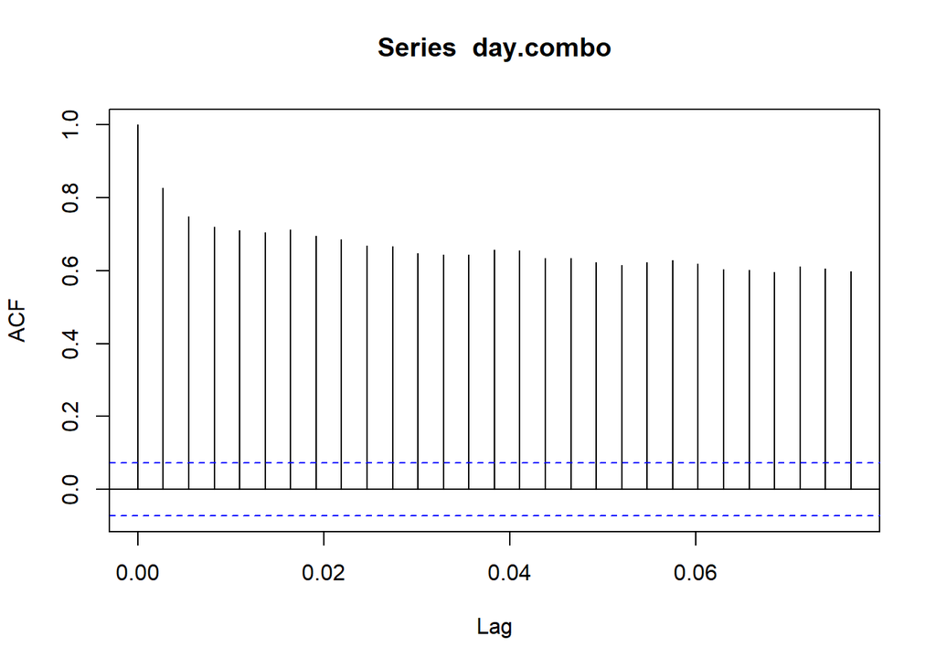

```r
acf(day.combo)
```

```r
normalTest(day.combo,method=c("jb"))
```

```
##
## Title:
##  Jarque - Bera Normalality Test
##
## Test Results:
##   STATISTIC:
##     X-squared: 47.2803
##   P VALUE:
##     Asymptotic p Value: 5.41e-11
##
## Description:
##  Mon Oct 14 21:43:08 2019 by user: kbaer
```

```r
autoplot(day_cnt.ts)
```

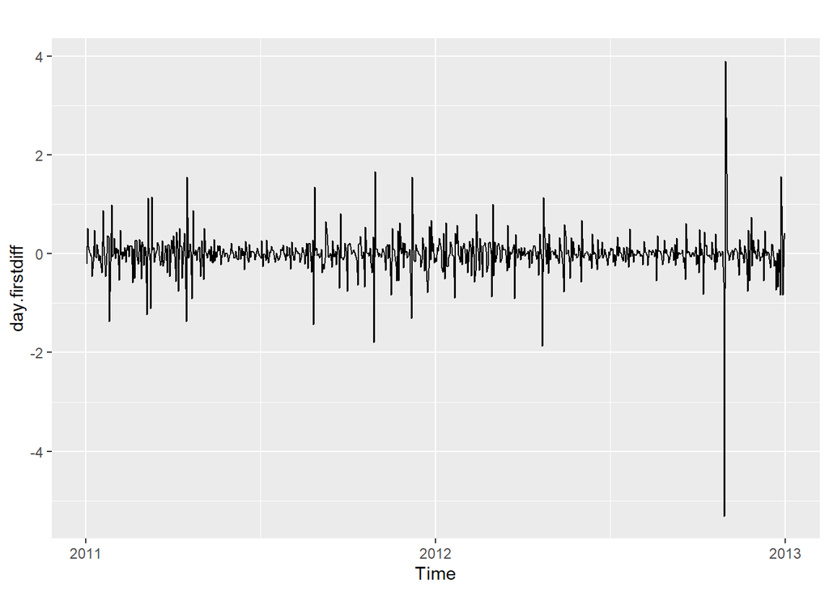

```r
day.firstdiff <- diff(day.log)
autoplot(day.firstdiff)
```

This is visually much better than our original series, however I’m still showing that there is a large peak and fall near the end of 2012. I’m going to quickly test if I should do second-order differencing:

```r
ndiffs(day.log) #no more differencing necessary
```

```
## [1] 1
```

Testing on my differenced data:

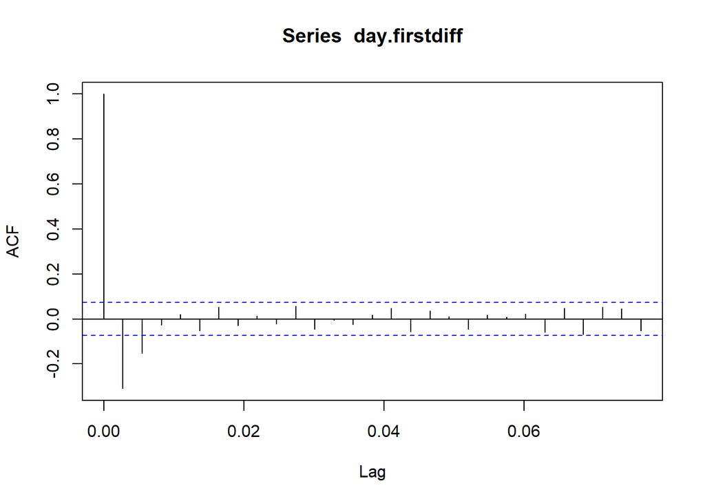

```r
acf(day.firstdiff)
```

```r
normalTest(day.firstdiff,method=c("jb"))
```

```
##
## Title:
##  Jarque - Bera Normalality Test
##
## Test Results:
##   STATISTIC:
##     X-squared: 72379.7951
##   P VALUE:
##     Asymptotic p Value: < 2.2e-16
##
## Description:
##  Mon Oct 14 21:43:08 2019 by user: kbaer
```

```r
Box.test(day.firstdiff,lag=10,type='Ljung')
```

```
##
##  Box-Ljung test
##
## data:  day.firstdiff
## X-squared = 95.326, df = 10, p-value = 4.441e-16
```

```r
summary(ur.kpss(day.firstdiff))
```

```
##
## #######################
## # KPSS Unit Root Test #
## #######################
##
## Test is of type: mu with 6 lags.
##
## Value of test-statistic is: 0.0364
##
## Critical value for a significance level of:
##                 10pct  5pct 2.5pct  1pct
## critical values 0.347 0.463  0.574 0.739
```

Much better, I only have three major lags but this seems to still be enough to throw off my normality tests. However, my unit root test shows a test statistic smaller than all of my critical values. For now I will move forward with the first-order differenced log series, but further transformations will take place during questions 3-5.

### *2. Decompose and forecast your time series using X11, SEATS and STL. Discuss your conclusions.*

For now I’ll return to using the standard ts object since we’re returning to decomposition:

```r
class(day_cnt.ts)
```

```
## [1] "ts"
```

```r
#day_cnt.ts %>%
  #(mean(...))

#fit.x11 <- seas(day_cnt.ts, x11="")
#autoplot(fit.x11) +  ggtitle("X11 Decomposition of Total Bikes Rented 2011-2012")

#fit.seats <- seas(day_cnt.ts)
#autoplot(fit.seats) +
  #ggtitle("SEATS Decomposition of Total Bikes Rented 2011-2012")
```

Unfortunately I was not able to decompose or forecast from X11 or SEATS; I first ensured I was using a ts object, then attempted aggregating the data since X11 requires monthly or quarterly data, but the output stated I needed a minimum of three years of data. I commented out the base code I was maniuplating so that it won’t interfere with the rest of my markdown. Based on the nature of this series, it seems that STL would be the best method of approaching a developed forecast anyway.

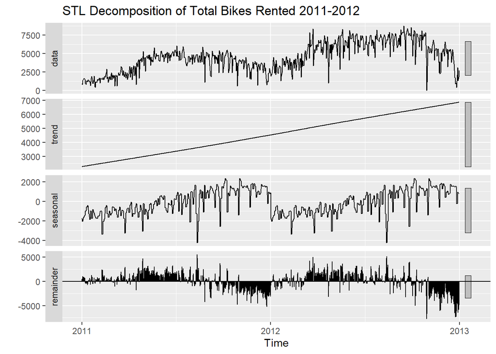

```r
#`t.window` controls wiggliness of trend component
#`s.window` controls variation on seasonal component. periodic means to use the default period

fit.stl <- stl(day_cnt.ts, s.window = "periodic", robust=TRUE)
autoplot(fit.stl) +
  ggtitle("STL Decomposition of Total Bikes Rented 2011-2012")
```

This is the same plot I produced in the beginning of my code, reintroduced for the purpose of this question. My trend line doesn’t seem to capture some inconsistencies in the data (seen through the remainder pattern), so I’m going to attempt adjusting the t.window:

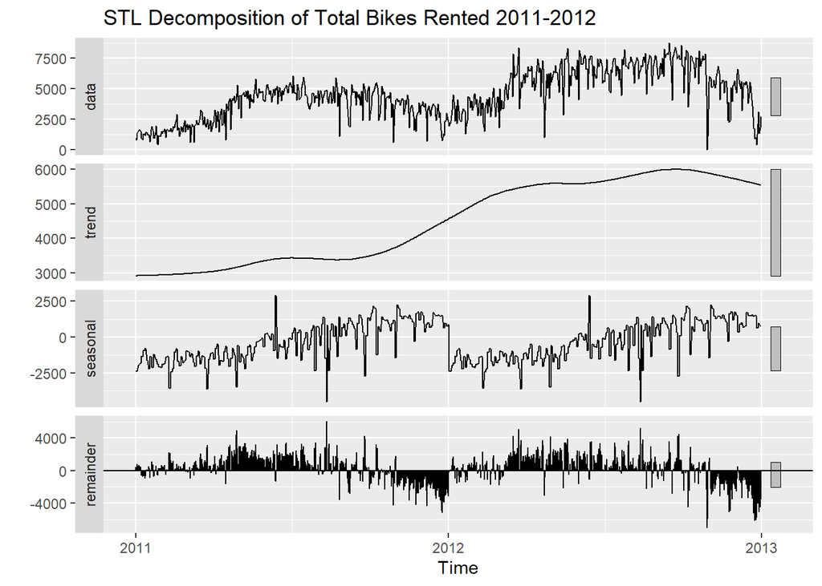

```r
fit.stl <- stl(day_cnt.ts, s.window = "periodic", t.window = 177, robust=TRUE)
autoplot(fit.stl) +
  ggtitle("STL Decomposition of Total Bikes Rented 2011-2012")
```

I played around with the t.window and selected an odd value near half of 365; I can see a trend that more closely resembles the peaks and valleys in my data, but this didn’t seem to help clear out remainder data.

Forecasting with STL:

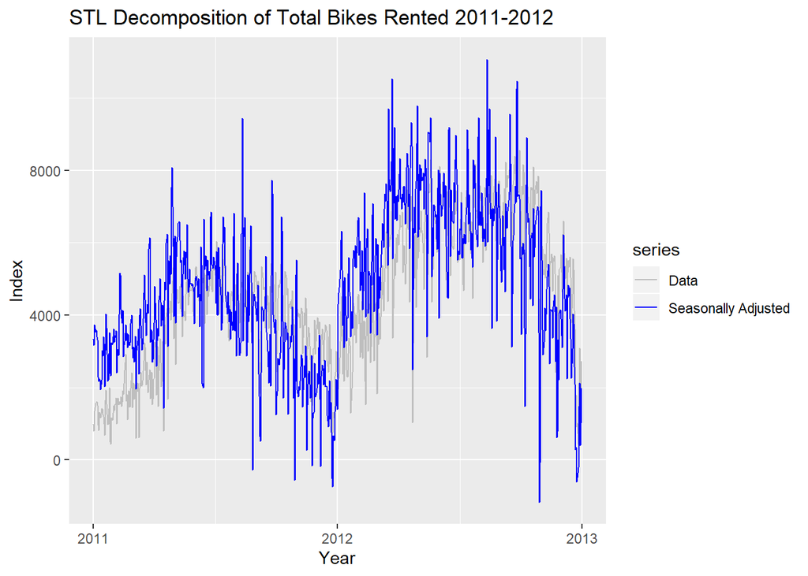

```r
autoplot(day_cnt.ts, series="Data") +
  autolayer(seasadj(fit.stl), series="Seasonally Adjusted") +
  xlab("Year") + ylab("Index") +
  ggtitle("STL Decomposition of Total Bikes Rented 2011-2012") +
  scale_colour_manual(values=c("gray","blue"),
                     breaks=c("Data","Seasonally Adjusted"))
```

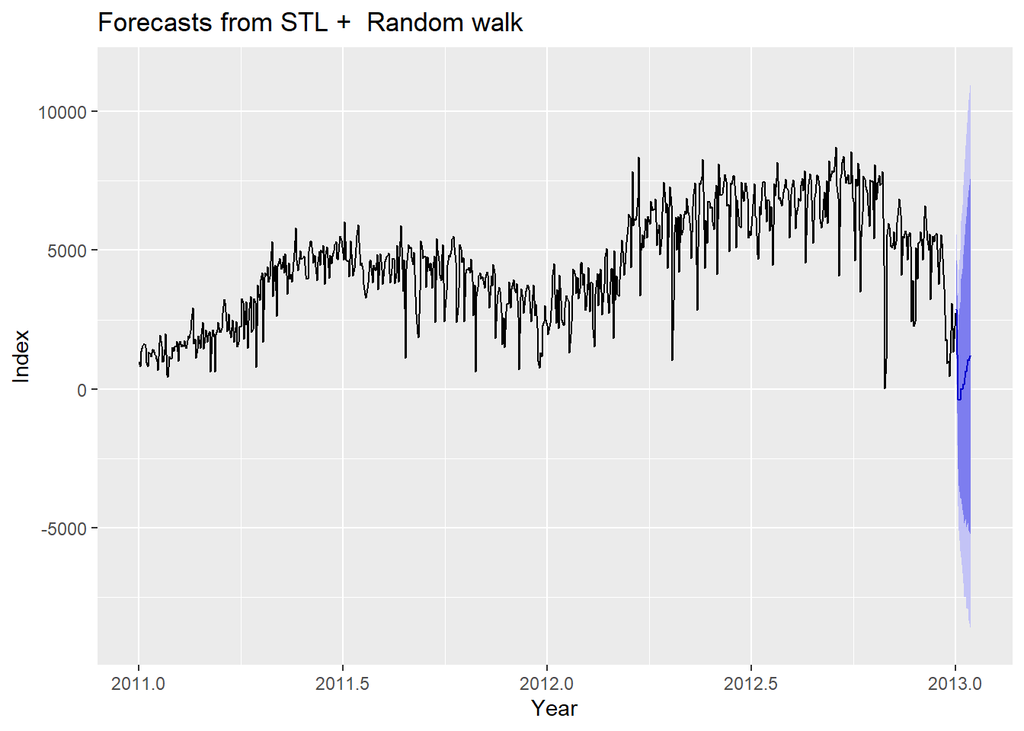

```r
fit.stl %>%
  forecast(method='naive', h=14) %>%
  autoplot() + ylab("Index") + xlab("Year")
```

```r
summary(fit.stl %>% forecast(method='naive')) # weight on more recent obs
```

```
##
## Forecast method: STL +  Random walk
##
## Model Information:
## Call: rwf(y = x, h = h, drift = FALSE, level = level)
##
## Residual sd: 1383.0509
##
## Error measures:
##                     ME     RMSE      MAE      MPE     MAPE      MASE
## Training set -1.860557 1382.104 942.8533 -34.9877 57.21692 0.4059381
##                    ACF1
## Training set -0.1931773
##
## Forecasts:
##           Point Forecast      Lo 80     Hi 80       Lo 95     Hi 95
## 2013.0014    2876.537727   1105.300  4647.776    167.6627  5585.413
## 2013.0041    -373.206792  -2878.116  2131.702  -4204.1346  3457.721
## 2013.0068    -396.852080  -3464.727  2671.022  -5088.7612  4295.057
## 2013.0096    -411.433402  -3953.910  3131.043  -5829.1834  5006.317
## 2013.0123       9.992640  -3950.616  3970.602  -6047.2360  6067.221
## 2013.0151      -4.635513  -4343.265  4333.994  -6639.9971  6630.726
## 2013.0178     173.991465  -4512.264  4860.247  -6993.0182  7341.001
## 2013.0205     159.316481  -4850.502  5169.135  -7502.5391  7821.172
## 2013.0233     642.433203  -4671.281  5956.148  -7484.1919  8769.058
## 2013.0260     627.711389  -4973.436  6228.858  -7938.5036  9193.926
## 2013.0287    1047.775208  -4826.757  6922.308  -7936.5468 10032.097
## 2013.0315    1033.006563  -5102.742  7168.756  -8350.8118 10416.825
## 2013.0342    1194.133115  -5192.157  7580.423  -8572.8547 10961.121
## 2013.0370    1179.315188  -5448.051  7806.682  -8956.3670 11314.997
## 2013.0397     373.478489  -6486.497  7233.454 -10117.9494 10864.906
## 2013.0424     358.611280  -6726.341  7443.564 -10476.8888 11194.111
## 2013.0452    -224.412485  -7527.415  7078.590 -11393.3903 10944.565
## 2013.0479    -239.328976  -7754.056  7275.398 -11732.1124 11253.454
## 2013.0507     627.675410  -7092.973  8348.324 -11180.0371 12435.388
## 2013.0534     612.709636  -7308.508  8533.928 -11501.7477 12727.167
## 2013.0561    -122.461616  -8239.295  7994.371 -12536.0864 12291.163
## 2013.0589    -137.476671  -8445.320  8170.367 -12843.2268 12568.273
## 2013.0616     775.406585  -7719.153  9269.966 -12215.9016 13766.715
## 2013.0643     760.342247  -7916.917  9437.602 -12510.3809 14031.065
```

[output cut: 691 more lines]

```
## 2014.9589    3504.364364 -43890.739 50899.468 -68980.1911 75988.920
## 2014.9617    3483.020990 -43945.168 50911.210 -69052.1345 76018.176
## 2014.9644    3496.822682 -43964.429 50958.074 -69088.8976 76082.543
## 2014.9671    3475.458260 -44018.833 50969.749 -69160.7916 76111.708
## 2014.9699    3527.462087 -43999.845 51054.770 -69159.2822 76214.206
## 2014.9726    3506.076615 -44054.224 51066.378 -69231.1270 76243.280
## 2014.9754    3441.318479 -44151.953 51034.590 -69346.3096 76228.947
## 2014.9781    3419.911959 -44206.308 51046.132 -69418.1056 76257.930
## 2014.9808    3499.006283 -44160.139 51158.151 -69389.3660 76387.379
## 2014.9836    3477.578714 -44214.469 51169.626 -69461.1134 76416.271
## 2014.9863    2625.200166 -45099.727 50350.127 -70363.7772 75614.178
## 2014.9890    2603.751548 -45154.033 50361.536 -70435.4764 75642.979
## 2014.9918    2942.509286 -44848.109 50733.128 -70146.9347 76031.953
## 2014.9945    2921.039618 -44902.391 50744.470 -70218.5859 76060.665
## 2014.9973    2750.490716 -45105.729 50606.711 -70439.2820 75940.263
```

STL makes sense with the daily data, but it would need further transformation and analysis. My RMSE is pretty high, and in the forecast I can see that the 95% CI is pretty large.

### *3. Fit and forecast at least 3* different smoothing models (which may include drift, additive or multiplicative and damp). Discuss your conclusions.*

1. Simple Exponential Smoothing (SES):

```r
fit.SES <- ses(day_cnt.ts, h = 14) # finding the optimal alpha smoothing parameter
summary(fit.SES)
```

```
##
## Forecast method: Simple exponential smoothing
##
## Model Information:
## Simple exponential smoothing
##
## Call:
##  ses(y = day_cnt.ts, h = 14)
##
##   Smoothing parameters:
##     alpha = 0.2833
##
##   Initial states:
##     l = 1170.2635
##
##   sigma:  965.8389
##
##      AIC     AICc      BIC
## 14872.84 14872.87 14886.62
##
## Error measures:
##                    ME     RMSE      MAE       MPE     MAPE      MASE
## Training set 4.592199 964.5168 688.6343 -49.25134 63.97796 0.2964861
##                   ACF1
## Training set 0.2068816
##
## Forecasts:
##           Point Forecast    Lo 80    Hi 80      Lo 95    Hi 95
## 2013.0014        2121.39 883.6178 3359.163  228.38062 4014.400
## 2013.0041        2121.39 834.8934 3407.887  153.86309 4088.917
## 2013.0068        2121.39 787.9482 3454.832   82.06663 4160.714
## 2013.0096        2121.39 742.6005 3500.180   12.71329 4230.067
## 2013.0123        2121.39 698.6975 3544.083  -54.43056 4297.211
## 2013.0151        2121.39 656.1093 3586.671 -119.56354 4362.344
## 2013.0178        2121.39 614.7245 3628.056 -182.85617 4425.636
## 2013.0205        2121.39 574.4464 3668.334 -244.45617 4487.236
## 2013.0233        2121.39 535.1908 3707.590 -304.49247 4547.273
## 2013.0260        2121.39 496.8835 3745.897 -363.07843 4605.859
## 2013.0287        2121.39 459.4589 3783.321 -420.31436 4663.095
## 2013.0315        2121.39 422.8587 3819.922 -476.28949 4719.070
## 2013.0342        2121.39 387.0308 3855.750 -531.08363 4773.864
## 2013.0370        2121.39 351.9281 3890.852 -584.76854 4827.549
```

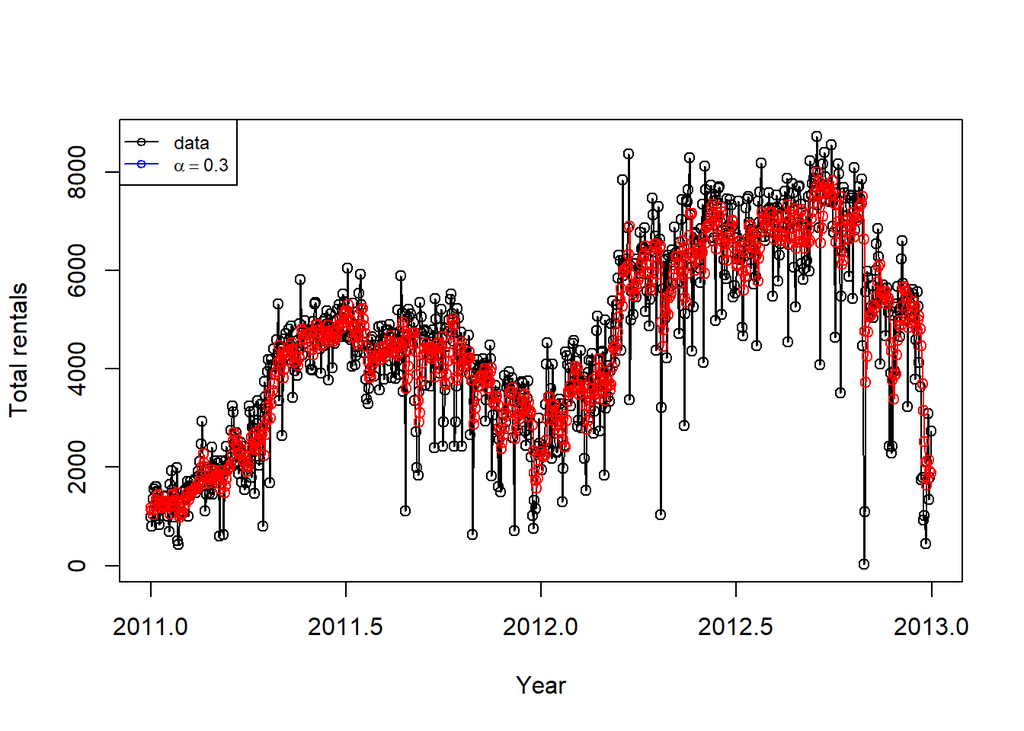

```r
plot(day_cnt.ts, PI=FALSE, ylab="Total rentals",
     xlab="Year", main="", fcol="white", type="o")
lines(fitted(fit.SES), col="red", type="o")

legend("topleft",lty=1, col=c(1,"blue","red"), cex = 0.75,
       c("data",expression(alpha == 0.3)),pch=1)
```

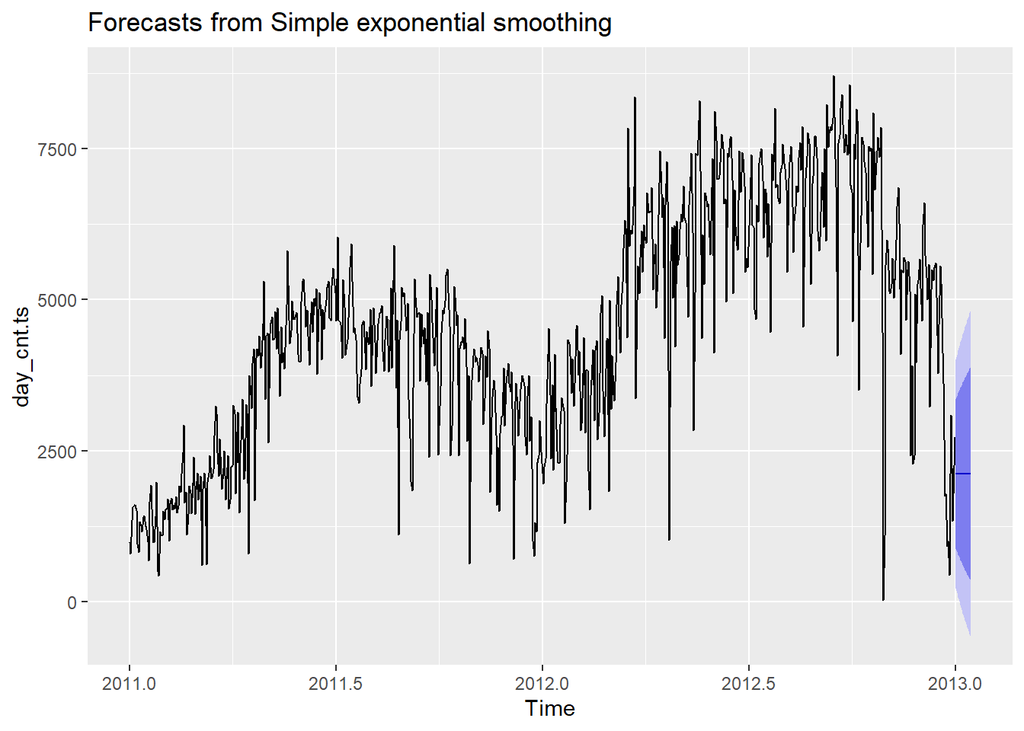

```r
autoplot(forecast(fit.SES), h=14)
```

As we learned in our class discussion, SES alone doesn’t account for trend in its forecast, so I ideally wouldn’t move forward with just this fit.

2. Holt’s Additive:

```r
#is.na(day_cnt.ts)
#na.omit(day_cnt.ts)

# When I tried using Holt's method with the ts object, it returned the 'length = zero' argument. It was successful when I instead used the bikes dataframe, though I can't explain why. The code commented out above was me attempting to comb for NA values in the ts. #

fit.holtadd <- holt(bikes, alpha=0.3, beta = 0.7, initial="simple", h=14)
summary(fit.holtadd)
```

```
##
## Forecast method: Holt's method
##
## Model Information:
## Holt's method
##
## Call:
##  holt(y = bikes, h = 14, initial = "simple", alpha = 0.3, beta = 0.7)
##
##   Smoothing parameters:
##     alpha = 0.3
##     beta  = 0.7
##
##   Initial states:
##     l = 1
##     b = 1
##
##   sigma:  456.7475
## Error measures:
##                    ME     RMSE      MAE  MPE MAPE     MASE      ACF1
## Training set 243.8193 1497.697 751.3896 -Inf  Inf 6.777288 0.9670682
##
## Forecasts:
##     Point Forecast      Lo 80     Hi 80      Lo 95     Hi 95
## 732       3119.129  2533.7836  3704.475  2223.9205  4014.338
## 733       3684.795  2856.9915  4512.598  2418.7788  4950.811
## 734       4250.461  2956.0663  5544.855  2270.8552  6230.066
## 735       4816.127  2905.8906  6726.363  1894.6727  7737.581
## 736       5381.793  2747.0877  8016.497  1352.3592  9411.226
## 737       5947.458  2499.3812  9395.536   674.0794 11220.837
## 738       6513.124  2174.0599 10852.189  -122.9021 13149.151
## 739       7078.790  1778.5849 12378.995 -1027.1743 15184.755
## 740       7644.456  1318.3907 13970.521 -2030.4259 17319.338
## 741       8210.122   797.6976 15622.546 -3126.2028 19546.447
## 742       8775.788   219.9272 17331.648 -4309.2717 21860.847
## 743       9341.454  -412.0598 19094.967 -5575.2579 24258.165
## 744       9907.119 -1095.8181 20910.057 -6920.4214 26734.660
## 745      10472.785 -1829.2210 22774.792 -8341.5098 29287.080
```

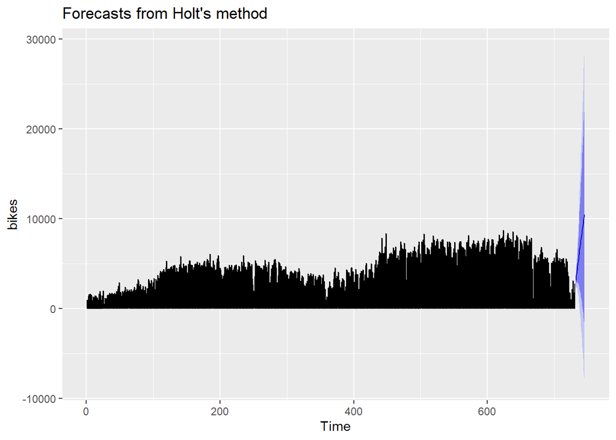

```r
autoplot(forecast(fit.holtadd), h=14)
```

There is an obvious fault in this fit and forecast because there are negative values. The forecast overall seems unreliable as well, as it’s anticipating the count of total rentals to skyrocket past the highest recorded count in 2012.

3. Dampened method:

```r
# Code wouldn't allow me to use alpha of 0.3, so I switched the parameters out of curiosity

fit.damp <- holt(day_cnt.ts, alpha=0.7, beta = 0.3, initial="simple", damped = TRUE, h=14)
summary(fit.damp)
```

```
##
## Forecast method: Damped Holt's method
##
## Model Information:
## Damped Holt's method
##
## Call:
##  holt(y = day_cnt.ts, h = 14, damped = TRUE, initial = "simple",
##
##  Call:
##      alpha = 0.7, beta = 0.3)
##
##   Smoothing parameters:
##     alpha = 0.7
##     beta  = 0.3
##     phi   = 0.8
##
##   Initial states:
##     l = 1215.8493
##     b = 45.2046
##
##   sigma:  1116.888
##
##      AIC     AICc      BIC
## 15084.26 15084.31 15102.63
##
## Error measures:
##                    ME     RMSE      MAE       MPE     MAPE      MASE
## Training set 1.440701 1113.062 780.3498 -34.99003 53.26258 0.3359735
##                    ACF1
## Training set -0.1118108
##
## Forecasts:
##           Point Forecast      Lo 80     Hi 80      Lo 95     Hi 95
## 2013.0014       2631.638  1200.2884  4062.988   442.5776  4820.699
## 2013.0041       2784.842   820.3959  4749.288  -219.5190  5789.203
## 2013.0068       2907.405   360.9603  5453.850  -987.0462  6801.857
## 2013.0096       3005.456  -136.2810  6147.192 -1799.4159  7810.327
## 2013.0123       3083.896  -649.0487  6816.841 -2625.1502  8792.942
## 2013.0151       3146.648 -1164.5443  7457.841 -3446.7518  9740.048
## 2013.0178       3196.850 -1675.1216  8068.822 -4254.1876 10647.888
## 2013.0205       3237.012 -2176.1813  8650.205 -5041.7526 11515.776
## 2013.0233       3269.141 -2665.0267  9203.308 -5806.3852 12344.667
## 2013.0260       3294.844 -3140.1859  9729.874 -6546.6851 13136.373
## 2013.0287       3315.407 -3600.9889 10231.803 -7262.3076 13893.121
## 2013.0315       3331.857 -4047.2912 10711.005 -7953.5763 14617.290
## 2013.0342       3345.017 -4479.2906 11169.325 -8621.2289 15311.263
## 2013.0370       3355.545 -4897.4020 11608.492 -9266.2484 15977.339
```

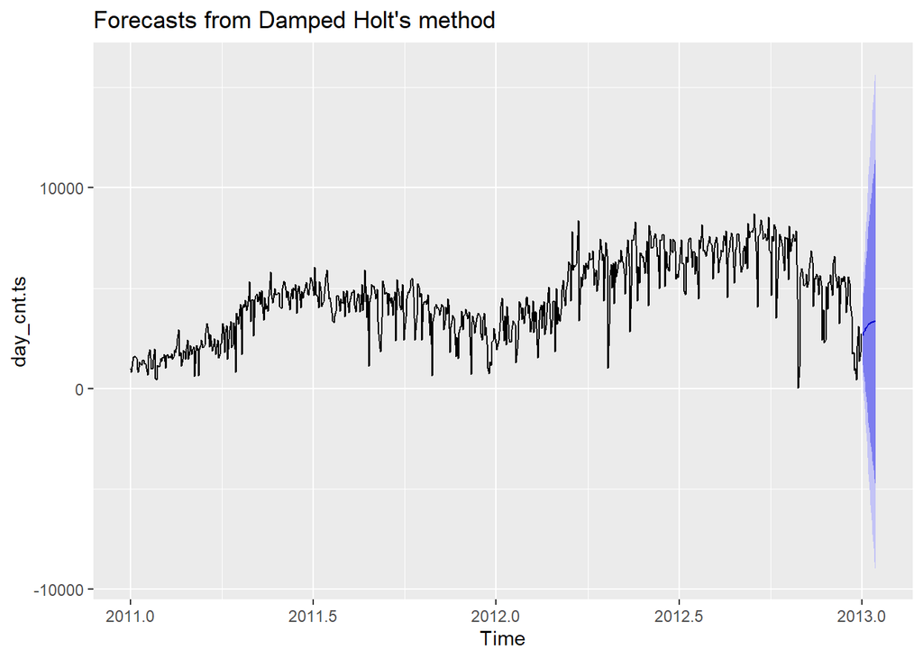

```r
autoplot(forecast(fit.damp), h=14)
```

Out of all of my attempts at smoothing, the damped model seems to have performed the most realistic forecast. However, my AICc and RMSE lead me to believe there’s significant room for improvement.

### *4. Fit and forecast at least 3 different ARIMA models (which may include seasonal and non-seasonal). Discuss your conclusions.*

I already know that I want to incorporate first-order differencing, so I will leave that as my constant. First, I will attempt non-seasonal.

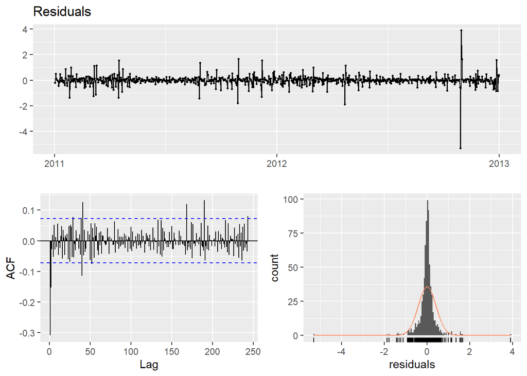

```r
checkresiduals(day.firstdiff)
```

(1) Non-Seasonal ARIMA(3,1,0)

```r
fit.arima.1 <- Arima(day_cnt.ts, order=c(3,1,0))
fit.arima.1
```

```
## Series: day_cnt.ts
## ARIMA(3,1,0)
##
## Coefficients:
##           ar1      ar2      ar3
##       -0.3947  -0.2819  -0.2004
## s.e.   0.0363   0.0377   0.0363
##
## sigma^2 estimated as 954741:  log likelihood=-6060.23
## AIC=12128.46   AICc=12128.51   BIC=12146.83
```

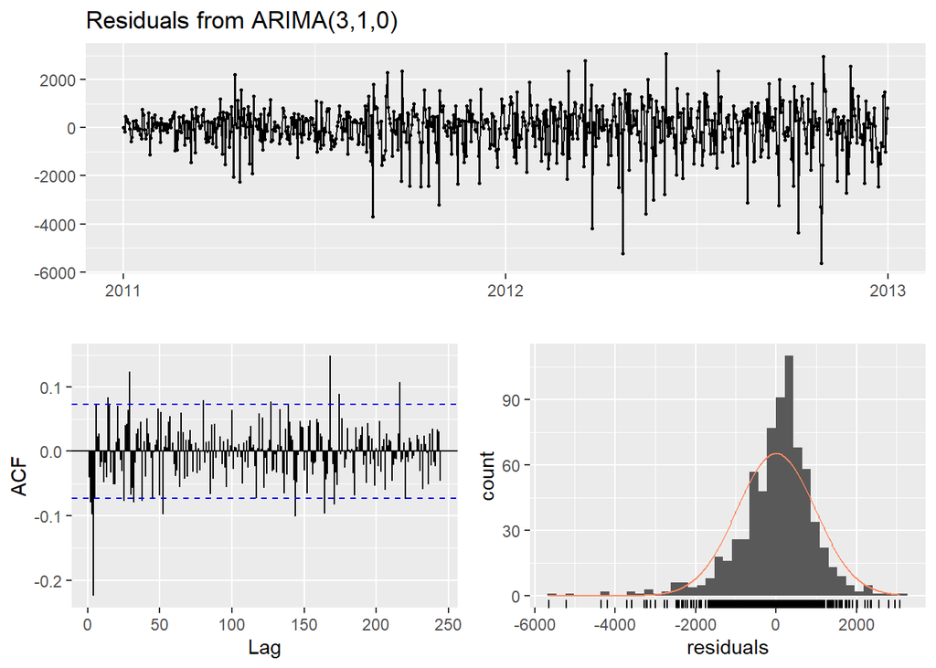

```
##
##  Ljung-Box test
##
## data:  Residuals from ARIMA(3,1,0)
## Q* = 252.78, df = 143, p-value = 4.191e-08
##
## Model df: 3.   Total lags used: 146
```

```r
checkresiduals(fit.arima.1)
```

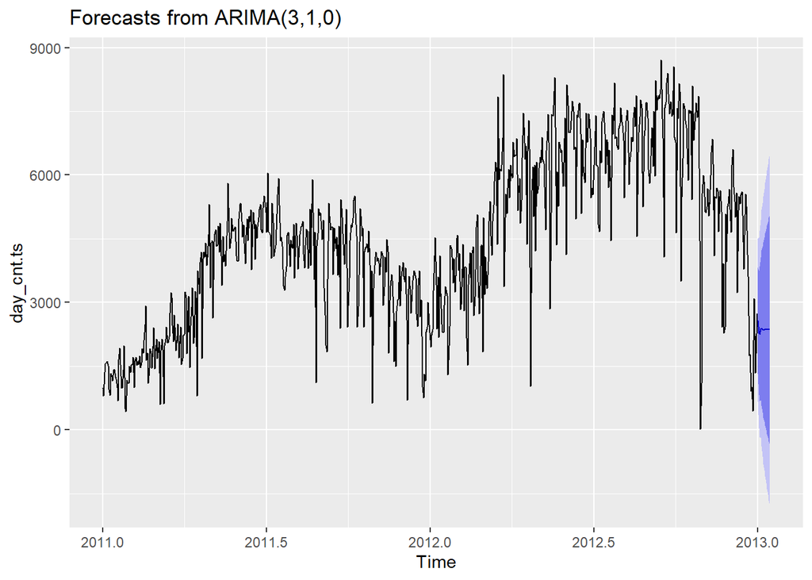

```r
autoplot(forecast(fit.arima.1, h = 14))
```

The ACF and stationary status of the residuals could be worse, but my AICc and pvalue tell me I should keep testing. From the residuals I ran on my first-order difference model, I feel like I should try non-seasonal with emphasis on the MA component.

2. Non-seasonal ARIMA (0,1,5)

Since there are 5 significant lags on my ACF for the first-order diff:

```r
fit.arima.2 <- Arima(day_cnt.ts, order=c(0,1,5))
fit.arima.2
```

```
## Series: day_cnt.ts
## ARIMA(0,1,5)
##
## Coefficients:
##           ma1      ma2      ma3      ma4     ma5
##       -0.5275  -0.2006  -0.1021  -0.0290  0.0396
## s.e.   0.0373   0.0428   0.0389   0.0422  0.0353
##
## sigma^2 estimated as 857524:  log likelihood=-6020.36
## AIC=12052.71   AICc=12052.83   BIC=12080.27
```

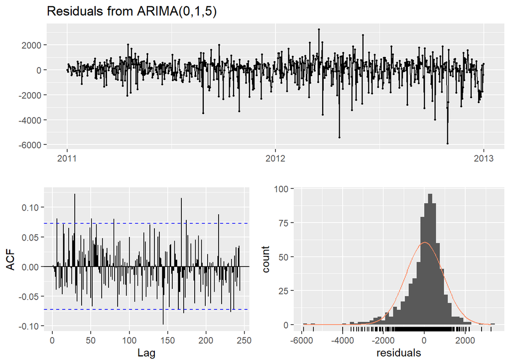

```
##
##  Ljung-Box test
##
## data:  Residuals from ARIMA(0,1,5)
## Q* = 167.5, df = 141, p-value = 0.06324
##
## Model df: 5.   Total lags used: 146
```

```r
checkresiduals(fit.arima.2)
```

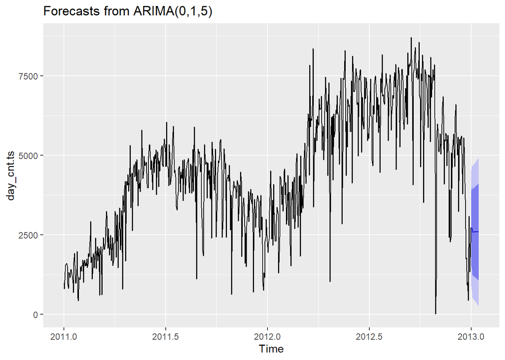

```r
autoplot(forecast(fit.arima.2, h = 14))
```

The residuals on my MA non-seasonal model are slightly better. Finally, I will test an auto.arima model, as I feel it will select a seasonal approach.

3. Seasonal auto.arima (1,0,2)(0,1,0)[365] with drift :

```r
library(tidyverse)
library(xts)
fit.auto <- auto.arima(day_cnt.ts, seasonal=TRUE)
fit.auto
```

```
## Series: day_cnt.ts
## ARIMA(1,0,2)(0,1,0)[365] with drift
##
## Coefficients:
##          ar1      ma1      ma2   drift
##       0.9586  -0.6363  -0.1892  5.7093
## s.e.  0.0283   0.0583   0.0506  0.7566
##
## sigma^2 estimated as 1600671:  log likelihood=-3131.76
## AIC=6273.52   AICc=6273.68   BIC=6293.03
```

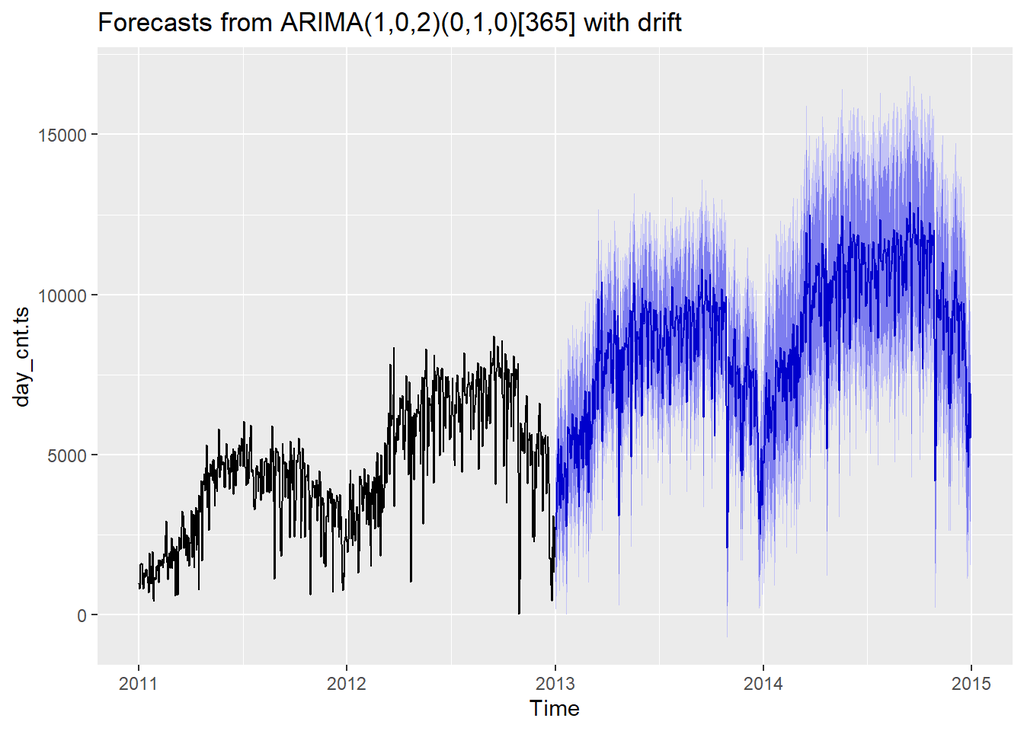

```r
autoplot(forecast(fit.auto), h=14)
```

The AICc is half of the value from my last model. I’ll check the residuals to compare:

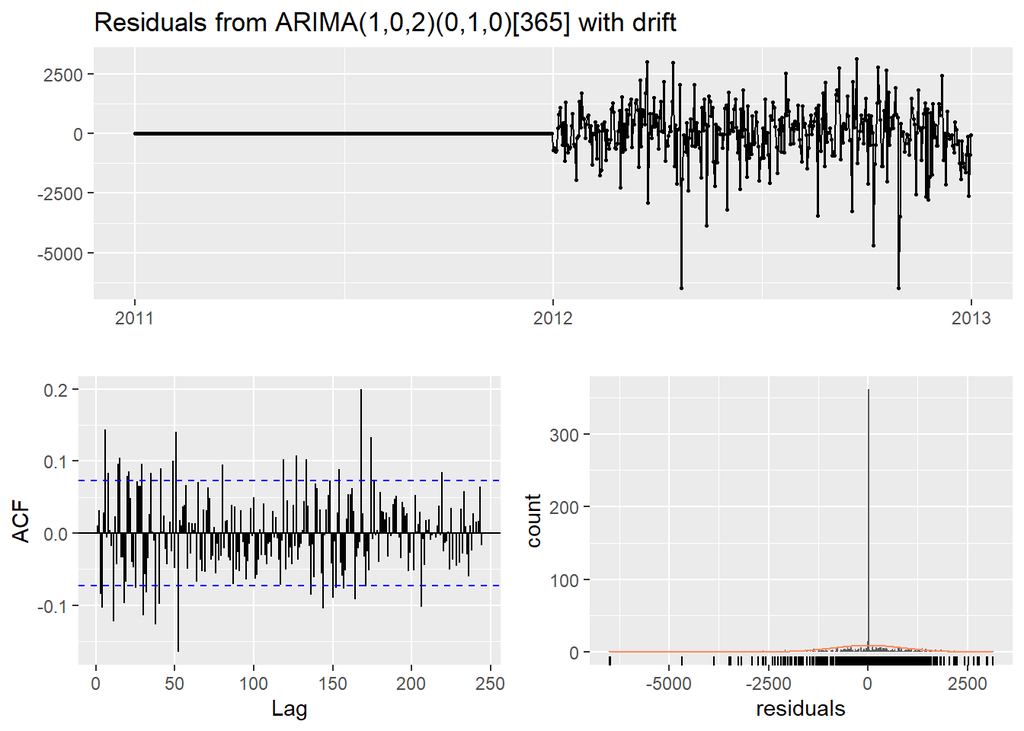

```
##
##  Ljung-Box test
##
## data:  Residuals from ARIMA(1,0,2)(0,1,0)[365] with drift
## Q* = 377.27, df = 142, p-value < 2.2e-16
##
## Model df: 4.   Total lags used: 146
```

```r
checkresiduals(fit.auto)
```

The residuals on this model look highly unusual, so I will test a fourth and final auto.arima without the seasonal component.

4. Non-seasonal auto.arima:

```r
fit.auto2 <- auto.arima(day_cnt.ts, seasonal=FALSE)

fit.auto2
```

```
## Series: day_cnt.ts
## ARIMA(1,1,1)
##
## Coefficients:
##          ar1      ma1
##       0.3584  -0.8896
## s.e.  0.0423   0.0192
##
## sigma^2 estimated as 857769:  log likelihood=-6021.96
## AIC=12049.91   AICc=12049.94   BIC=12063.69
```

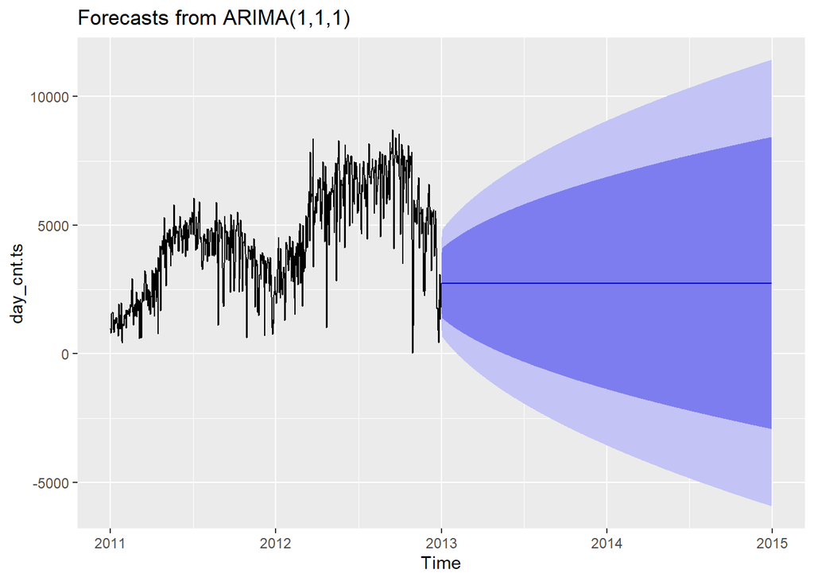

```r
autoplot(forecast(fit.auto2), h=14)
```

This model has a slightly better AICc than my MA non-seasonal model, but I’ll doublecheck the residuals

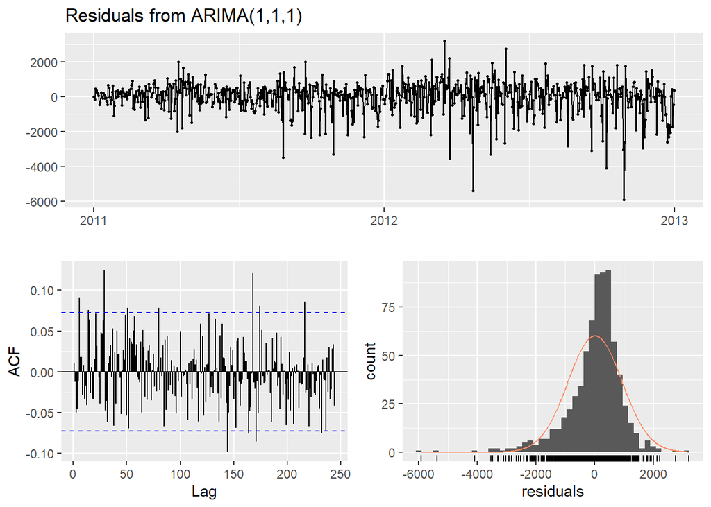

```
##
##  Ljung-Box test
##
## data:  Residuals from ARIMA(1,1,1)
## Q* = 177.15, df = 144, p-value = 0.03148
##
## Model df: 2.   Total lags used: 146
```

```r
checkresiduals(fit.auto2)
```

### *5. Fit and forecast at least 3* different dynamic regression models using a set or subset of other covariates which are in the dataset (cnt is still your DV). The covariates may need lagged too. Then discuss your conclusions.*

1. First forecast; manual non-seasonal ARIMA (1,1,1) with ‘weekday’ covariate

I’m going to borrow my ARIMA that performed the best from the last part of the homework to start:

```r
dynamic.reg.model1 <- Arima(day_cnt.ts, xreg= bikes[, "weekday"], order=c(1,1,1))

dynamic.reg.model1
```

```
## Series: day_cnt.ts
## Regression with ARIMA(1,1,1) errors
##
## Coefficients:
##          ar1      ma1     xreg
##       0.3538  -0.8874  57.9901
## s.e.  0.0427   0.0196  16.4706
##
## sigma^2 estimated as 844622:  log likelihood=-6015.81
## AIC=12039.62   AICc=12039.68   BIC=12058
```

AICc isn’t much better, but I’ll doublcheck the residuals:

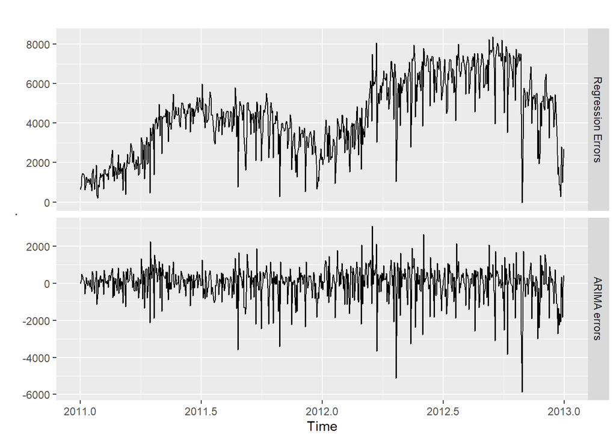

```r
cbind("Regression Errors" = residuals(dynamic.reg.model1, type="regression"),
      "ARIMA errors" = residuals(dynamic.reg.model1, type="innovation")) %>%
  autoplot(facets=TRUE)
```

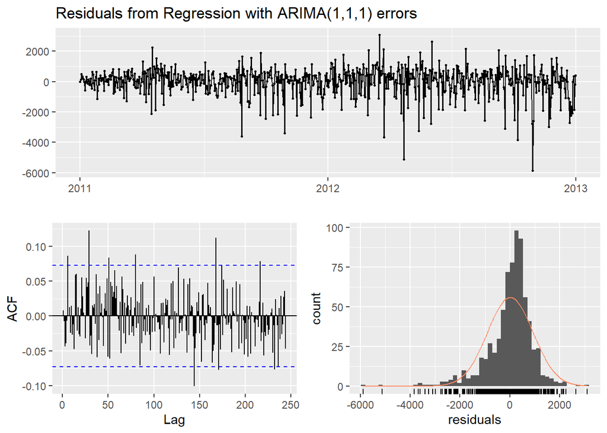

```
##
##  Ljung-Box test
##
## data:  Residuals from Regression with ARIMA(1,1,1) errors
## Q* = 161.09, df = 143, p-value = 0.1431
##
## Model df: 3.   Total lags used: 146
```

```r
checkresiduals(dynamic.reg.model1)
```

It could be worse! There are some significant lags in the ACF plot and the distribution isn’t very even, but the p value is above 0.05.

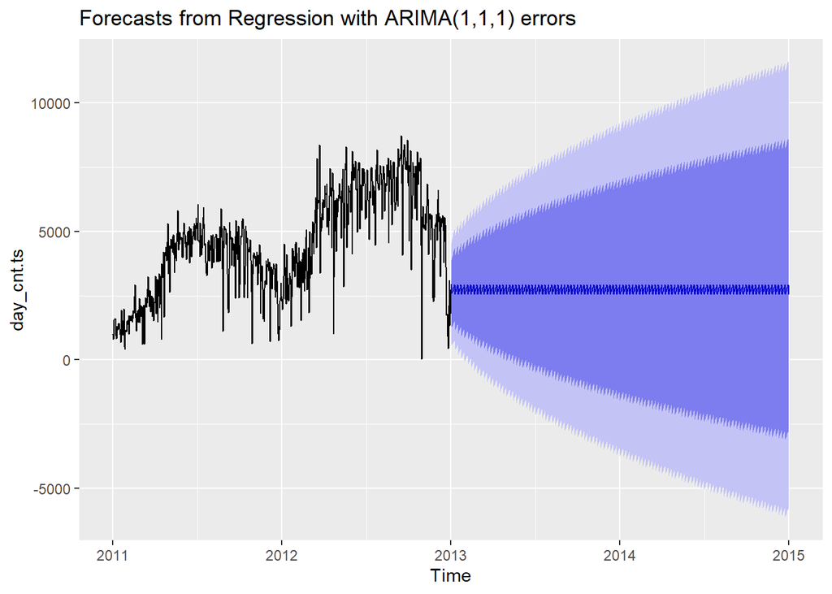

```r
fcast1 <- forecast(dynamic.reg.model1, xreg=bikes[, "weekday"], 14)
autoplot(fcast1)
```

(2) Second forecast; manual non-seasonal ARIMA (1,1,1) with ‘season’ covariate

```r
dynamic.reg.model2 <- Arima(day_cnt.ts, xreg= bikes[, "season"], order=c(1,1,1))

dynamic.reg.model2
```

```
## Series: day_cnt.ts
## Regression with ARIMA(1,1,1) errors
##
## Coefficients:
##          ar1      ma1      xreg
##       0.3394  -0.8981  440.8159
## s.e.  0.0409   0.0168  117.8722
##
## sigma^2 estimated as 843663:  log likelihood=-6015.45
## AIC=12038.9   AICc=12038.96   BIC=12057.28
```

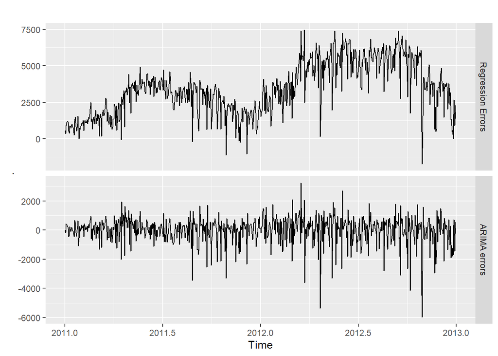

```r
cbind("Regression Errors" = residuals(dynamic.reg.model2, type="regression"),
      "ARIMA errors" = residuals(dynamic.reg.model2, type="innovation")) %>%
  autoplot(facets=TRUE)
```

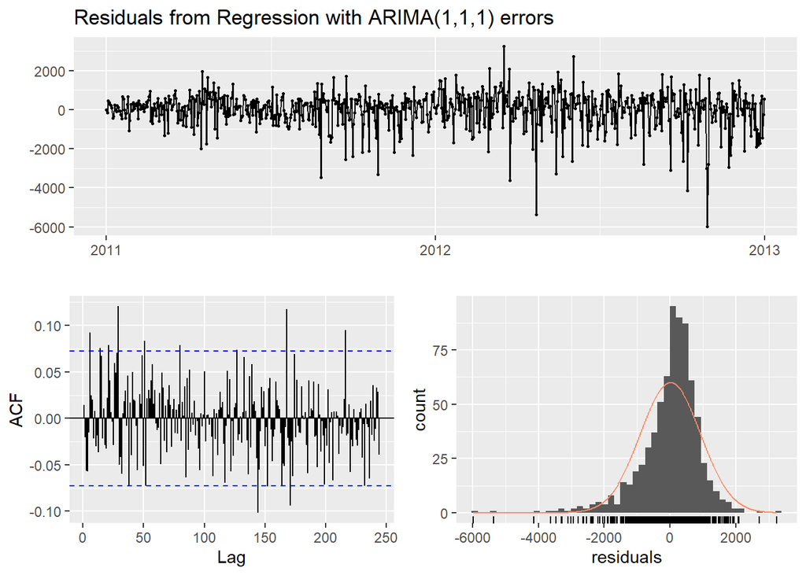

```
##
##  Ljung-Box test
##
## data:  Residuals from Regression with ARIMA(1,1,1) errors
## Q* = 179.9, df = 143, p-value = 0.01984
##
## Model df: 3.   Total lags used: 146
```

```r
checkresiduals(dynamic.reg.model2)
```

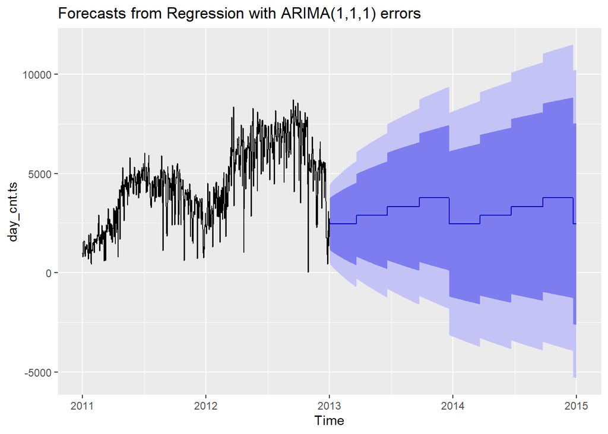

```r
fcast2 <- forecast(dynamic.reg.model2, xreg=bikes[, "season"], 14)
autoplot(fcast2)
```

There isn’t much of a visible difference aside from the forecast plot and p value. I’m going to attempt a different approach for my last model.

3. Third forecast; manual non-seasonal ARIMA (1,1,1) with ‘mnth’ covariate

```r
dynamic.reg.model3 <- Arima(day_cnt.ts, xreg= bikes[, "mnth"], order=c(1,1,1))

dynamic.reg.model3
```

```
## Series: day_cnt.ts
## Regression with ARIMA(1,1,1) errors
##
## Coefficients:
##          ar1      ma1      xreg
##       0.3584  -0.8897  -14.9758
## s.e.  0.0422   0.0191   50.4141
##
## sigma^2 estimated as 858841:  log likelihood=-6021.91
## AIC=12051.82   AICc=12051.88   BIC=12070.19
```

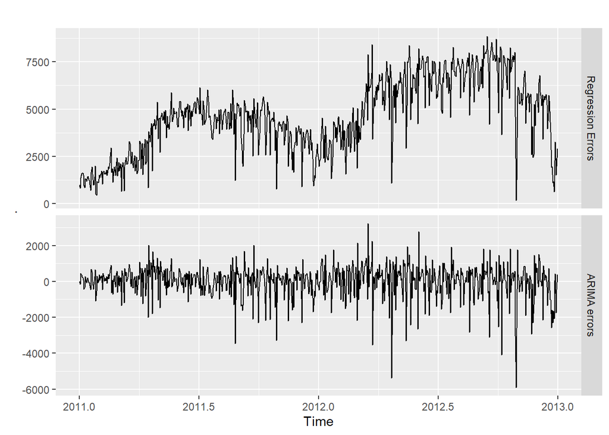

```r
cbind("Regression Errors" = residuals(dynamic.reg.model3, type="regression"),
      "ARIMA errors" = residuals(dynamic.reg.model3, type="innovation")) %>%
  autoplot(facets=TRUE)
```

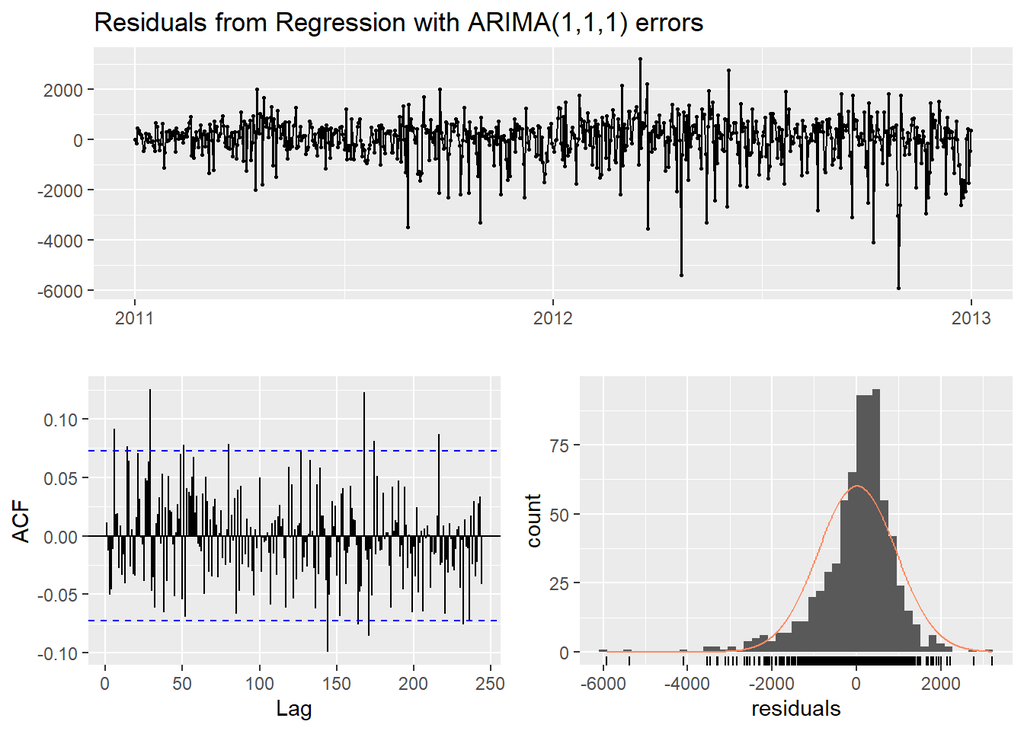

```
##
##  Ljung-Box test
##
## data:  Residuals from Regression with ARIMA(1,1,1) errors
## Q* = 177.7, df = 143, p-value = 0.0259
##
## Model df: 3.   Total lags used: 146
```

```r
checkresiduals(dynamic.reg.model3)
```

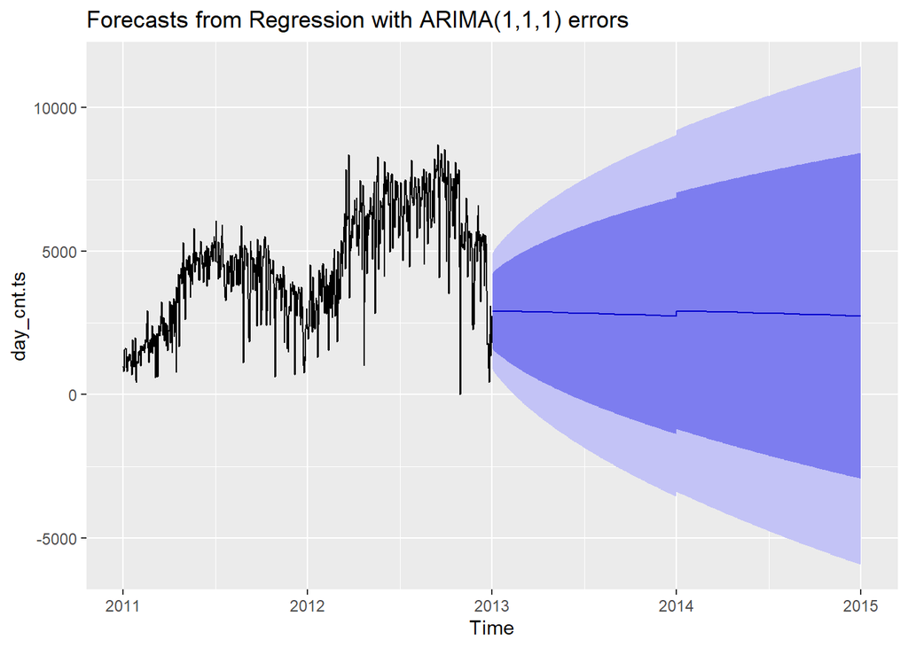

```r
# When I attempted auto.arima with the day_cnt ts object, my Rstudio would freeze, so I carried forward with another manual ARIMA instead #

fcast3 <- forecast(dynamic.reg.model3, xreg=bikes[, "mnth"], 14)
autoplot(fcast3)
```

This seems to have performed the worst of my dynamic regression attempts. If I were to continue with dynamic regression, I would likely revisit the structure of my ARMA/ARIMA and then apply the dynamic regression method.